# Import and local transmission analysis

The input for this analysis is the results from the maximum likelihood mapping of the geographical states on the full phylogenetic tree of the 9732 genomes.

## Import versus local transmission for Norway, Australia, Europe and the USA

From the mapped geographical lineage distributions we can derive the number of importation and local transmission events for each location (based on the available sequences). NB. we do not account for unobserved infections (sequences), and hence the estimated number only reflects the fraction of *sequenced* genomes that is assigned to specific lineages. The relative growth between the lineages (growth of an transmission lineage implies local transmission), is an important quantity and tells us how dominant specific lineages have become over time. This too could be affected by nonrandom sampling such as targeted sampling of lineages with anitibiotic resistance.

## Cumulative growth of transmission lineages

The following plots show the cumulative number of sequences obtained from each estimated transmission lineage over time

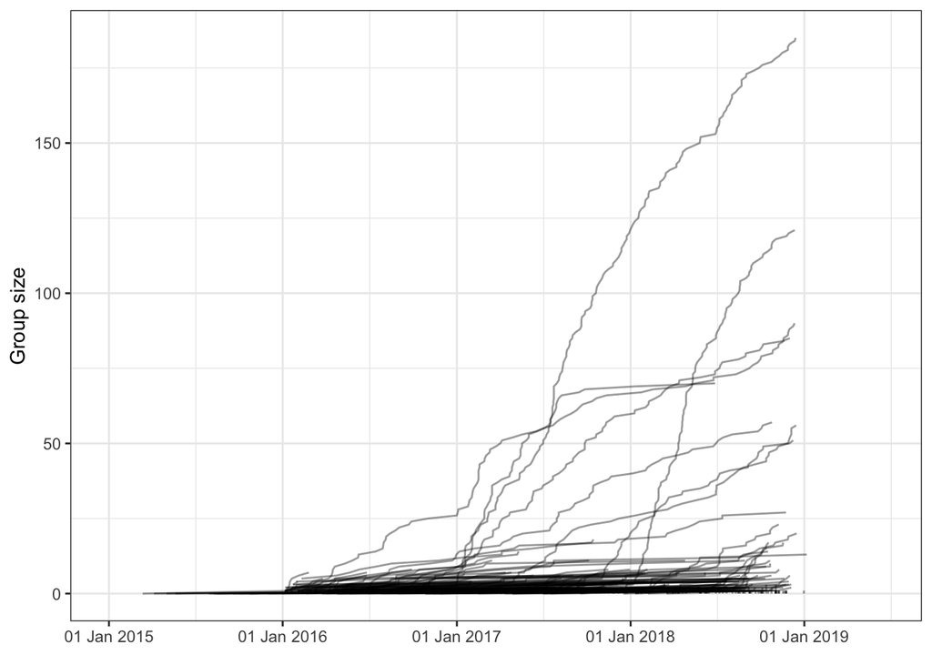

```r
name_date_NOR = name_date[name_date$name%in%nor_tips,]
linfo_NOR = lineage_info(Result_NOR,name_date = name_date_NOR)
LineageHomology::lineage_growth_cumulative(linfo_NOR,datelims=c("2015-01-01","2019-06-15","1 year"))
```

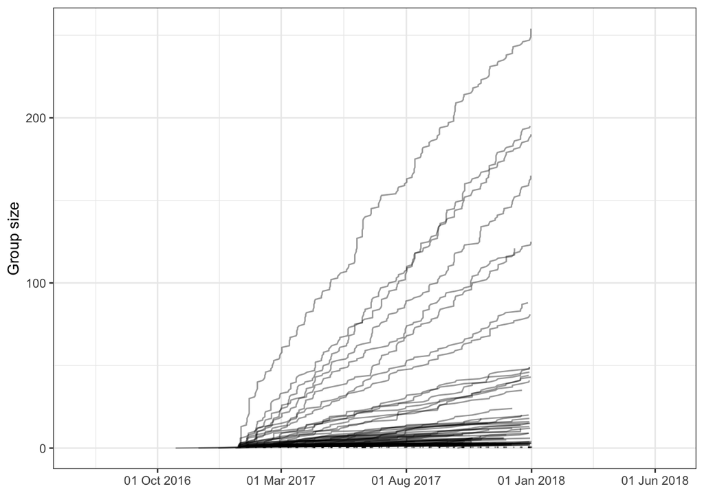

```r
name_date_AUS = name_date[name_date$name%in%aus_tips,]
linfo_AUS = lineage_info(Result_AUS,name_date = name_date_AUS)
LineageHomology::lineage_growth_cumulative(linfo_AUS,datelims=c("2016-07-01","2018-06-15","5 months"))
```

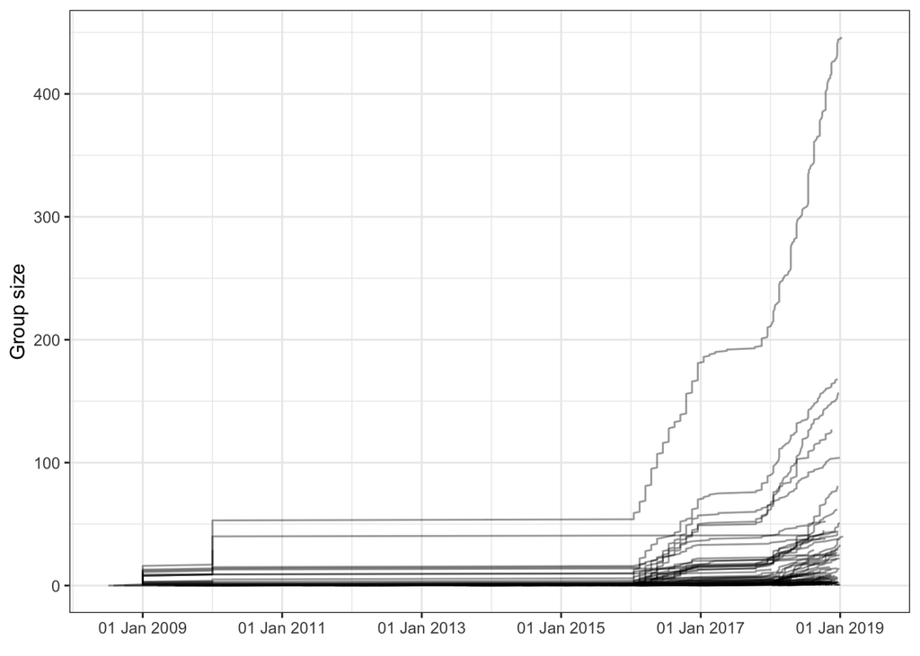

```r
name_date_USA = name_date[name_date$name%in%usa_tips,]
linfo_USA = lineage_info(Result_USA,name_date = name_date_USA)
LineageHomology::lineage_growth_cumulative(linfo_USA,datelims=c("2008-07-01","2019-06-15","2 year"))
```

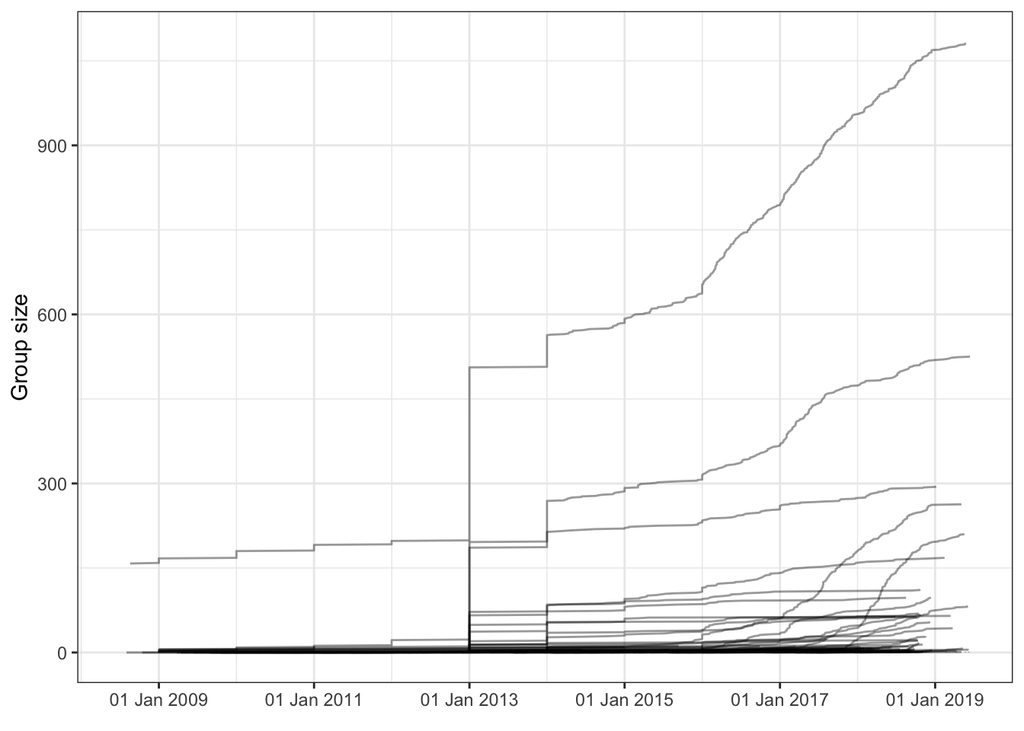

```r
name_date_EUR = name_date[name_date$name%in%eur_tips,]
linfo_EUR = lineage_info(Result_EUR,name_date = name_date_EUR)
LineageHomology::lineage_growth_cumulative(linfo_EUR,datelims=c("2008-07-01","2019-06-15","2 year"))
```

## Import and local transmission over time

```r
c1 = Summarize_import_export_local_transmission(implocexp_NOR); c1
```

```
##                        2.5%    50%   97.5%
## Import              706.850  736.0  764.00
## Local transmission 1929.425 1967.5 2004.05
## Export              922.475  980.5 1028.00
```

```r
c2 = Summarize_import_export_local_transmission(implocexp_AUS); c2
```

```
##                        2.5%    50%    97.5%
## Import              356.475  371.5  391.000
## Local transmission 2152.000 2175.0 2199.050
## Export              312.475  346.0  381.675
```

```r
c3 = Summarize_import_export_local_transmission(implocexp_USA); c3
```

```
##                        2.5%    50%    97.5%
## Import              370.950  390.0  407.575
## Local transmission 2574.375 2595.5 2620.100
## Export              586.900  617.0  645.000
```

```r
c3 = Summarize_import_export_local_transmission(implocexp_EUR); c3
```

```
##                        2.5%    50%    97.5%
## Import              449.475  476.0  499.525
## Local transmission 4233.950 4266.5 4306.000
## Export              620.000  643.5  662.000
```

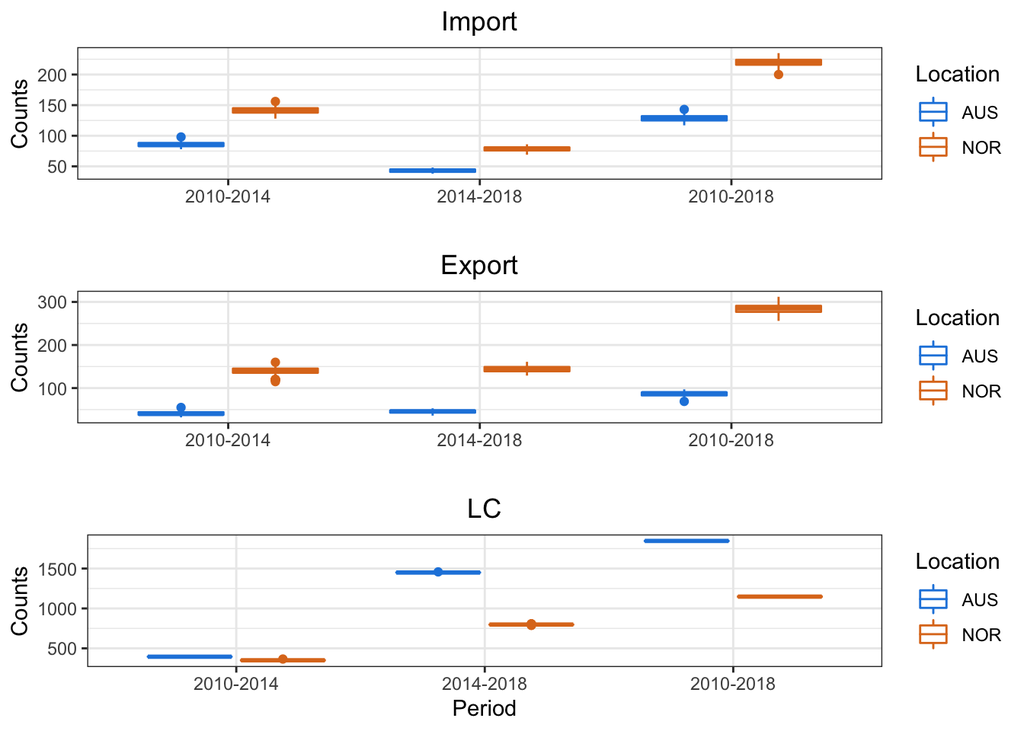

```r
ggdat1 = make_boxplot_frame_import_export_local_transmission(implocexp_NOR, location="NOR")
ggdat2 = make_boxplot_frame_import_export_local_transmission(implocexp_AUS, location="AUS")
comparison_NOR_AUS = rbind(ggdat1, ggdat2)

ggdat1 = make_boxplot_frame_import_export_local_transmission(implocexp_USA, location="USA")
ggdat2 = make_boxplot_frame_import_export_local_transmission(implocexp_EUR, location="EUR")
comparison_USA_EUR = rbind(ggdat1, ggdat2)

g1 = boxplot_boxplot_frame(comparison_NOR_AUS,variable="Import")
g2 = boxplot_boxplot_frame(comparison_NOR_AUS, variable="Export")
g3 = boxplot_boxplot_frame(comparison_NOR_AUS, variable="LC", x_lab="Period")

grid.arrange(g1,g2,g3)
```

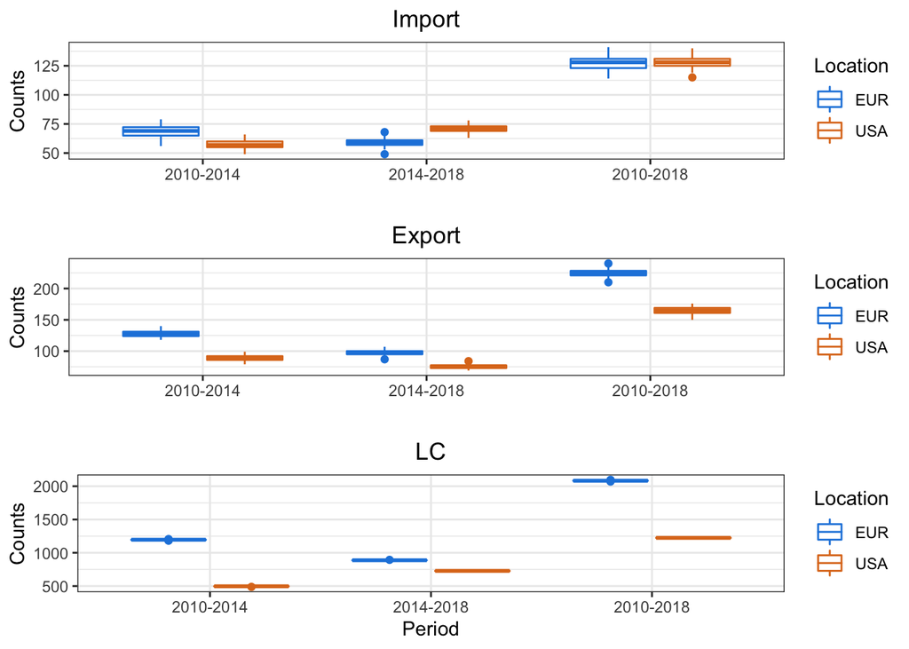

```r
g4 = boxplot_boxplot_frame(comparison_USA_EUR,variable="Import")
g5 = boxplot_boxplot_frame(comparison_USA_EUR, variable="Export")
g6 = boxplot_boxplot_frame(comparison_USA_EUR, variable="LC", x_lab="Period")

grid.arrange(g4,g5,g6)
```

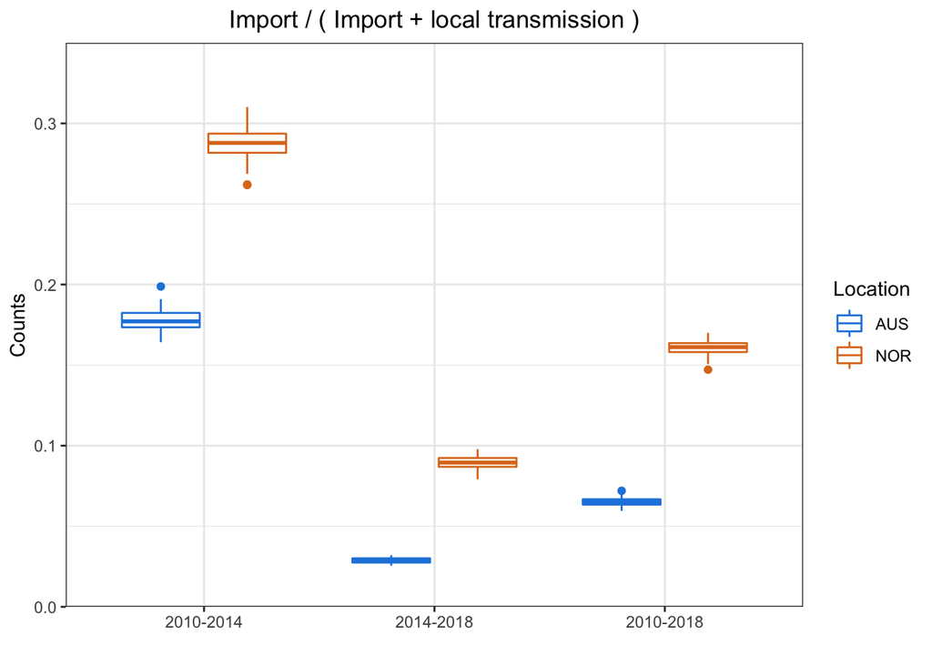

```r
# Import / (Import + LC)
#pdf(paste0(path_results,"Import_by_LC_NOR_AUS.pdf"), width=10, height=10)
boxplot_boxplot_frame_import_by_LC(comparison_NOR_AUS)
```

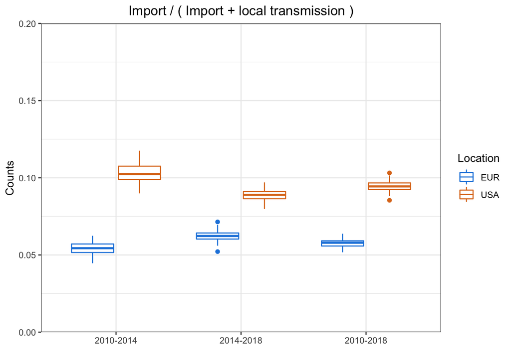

```r
#dev.off()

#pdf(paste0(path_results,"Import_by_LC_USA_EUR.pdf"), width=10, height=10)
boxplot_boxplot_frame_import_by_LC(comparison_USA_EUR, ylims=c(0,0.2))
```

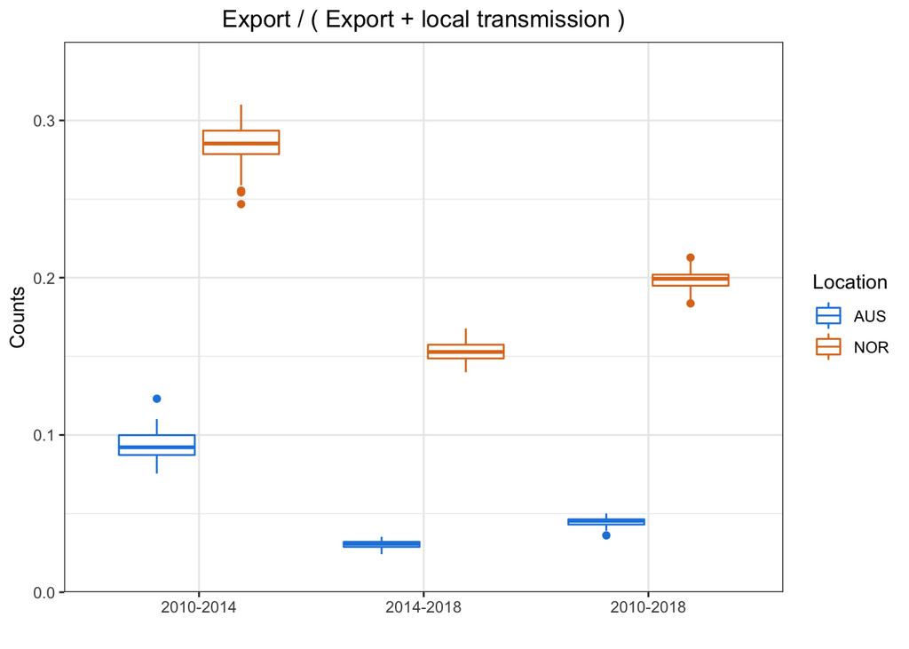

```r
#dev.off()



#Export
#pdf(paste0(path_results,"Export_by_LC_NOR_AUS.pdf"), width=10, height=10)
boxplot_boxplot_frame_Export_by_LC(comparison_NOR_AUS)
```

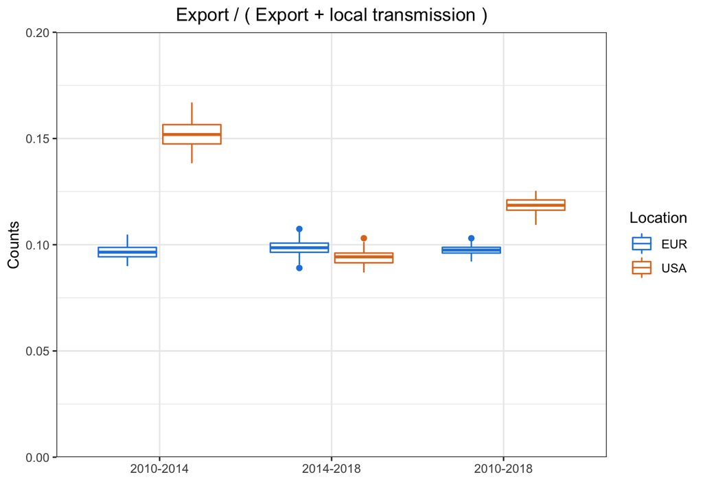

```r
#dev.off()

#pdf(paste0(path_results,"Export_by_LC_USA_EUR.pdf"), width=10, height=10)
boxplot_boxplot_frame_Export_by_LC(comparison_USA_EUR, ylims=c(0,0.2))
```

```r
#dev.off()

#
# utility_f1(implocexp_NOR)
# utility_f1(implocexp_AUS)
# utility_f1(implocexp_USA)
# utility_f1(implocexp_EUR)
```

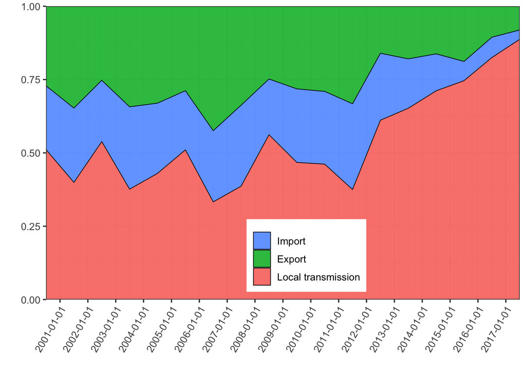

```r
#pdf("/Users/magnusnygardosnes/Dropbox/10000_Lovers/Junk_used_for_exploratory/Temp/imp_exp_loc_NOR.pdf", width = 10, height = 8)
plot_relative_fraction(implocexp_NOR)
```

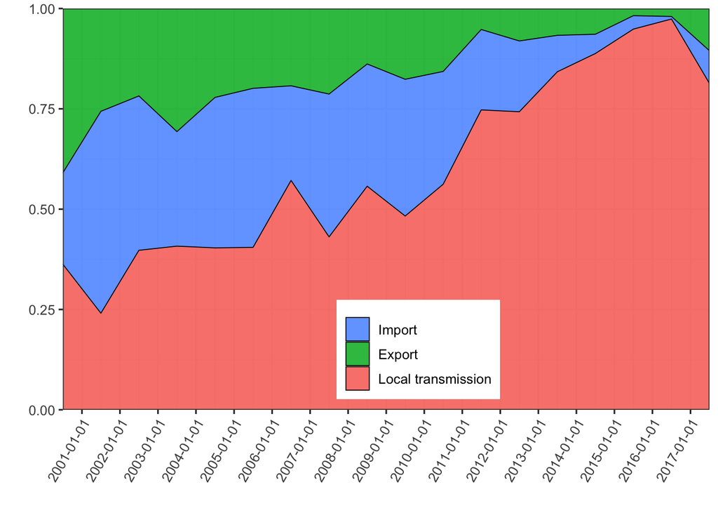

```r
#dev.off()

#pdf("/Users/magnusnygardosnes/Dropbox/10000_Lovers/Junk_used_for_exploratory/Temp/imp_exp_loc_AUS.pdf", width = 10, height = 8)
plot_relative_fraction(implocexp_AUS)
```

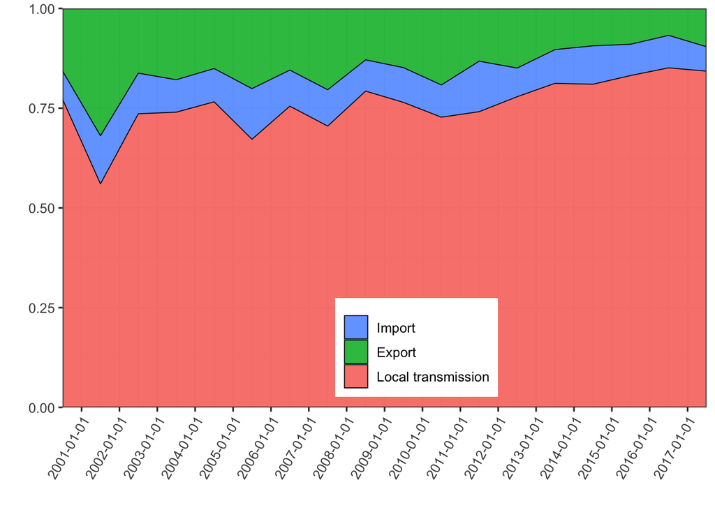

```r
#dev.off()

#pdf("/Users/magnusnygardosnes/Dropbox/10000_Lovers/Junk_used_for_exploratory/Temp/imp_exp_loc_USA.pdf", width = 10, height = 8)
plot_relative_fraction(implocexp_USA)
```

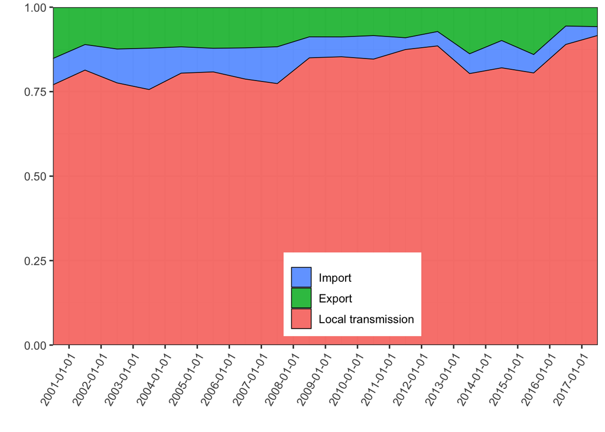

```r
#dev.off()


#pdf("/Users/magnusnygardosnes/Dropbox/10000_Lovers/Junk_used_for_exploratory/Temp/imp_exp_loc_EUR.pdf", width = 10, height = 8)
plot_relative_fraction(implocexp_EUR)
```

```r
#dev.off()
```

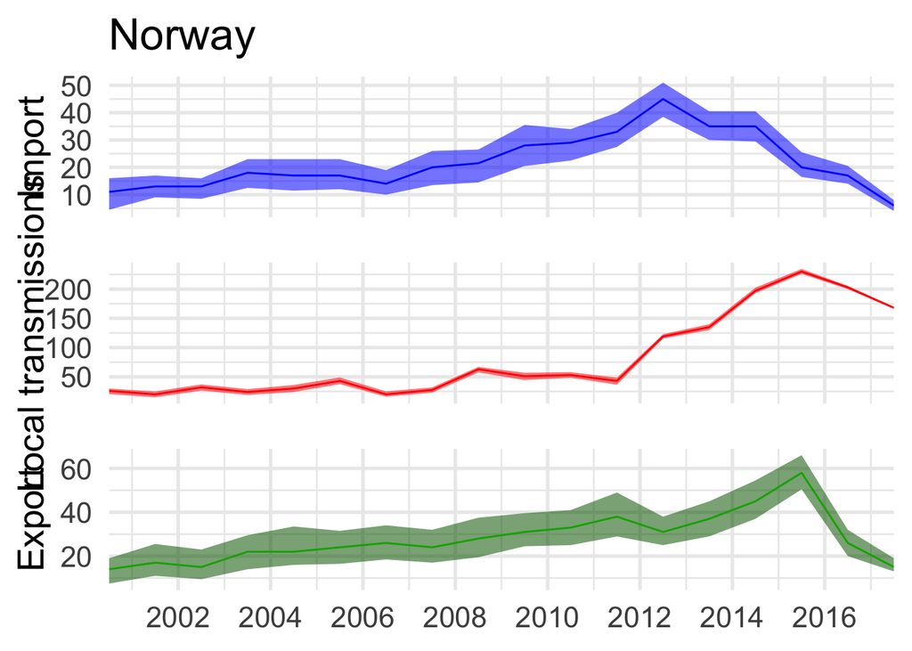

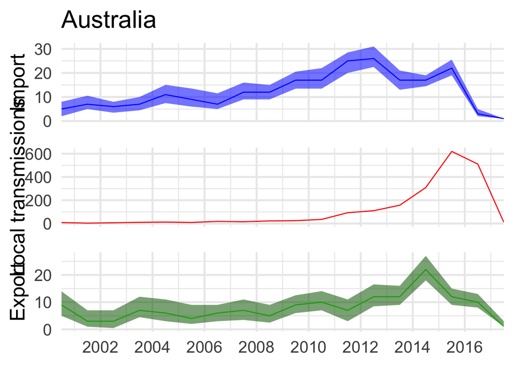

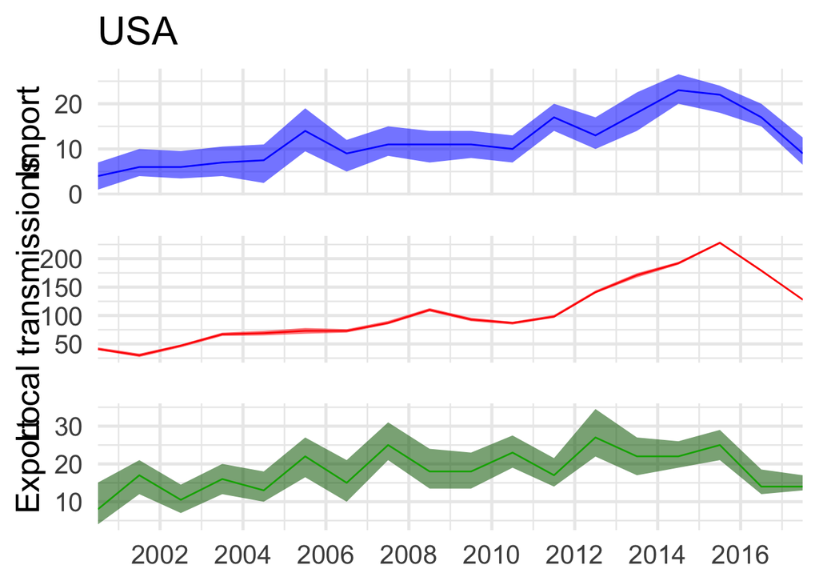

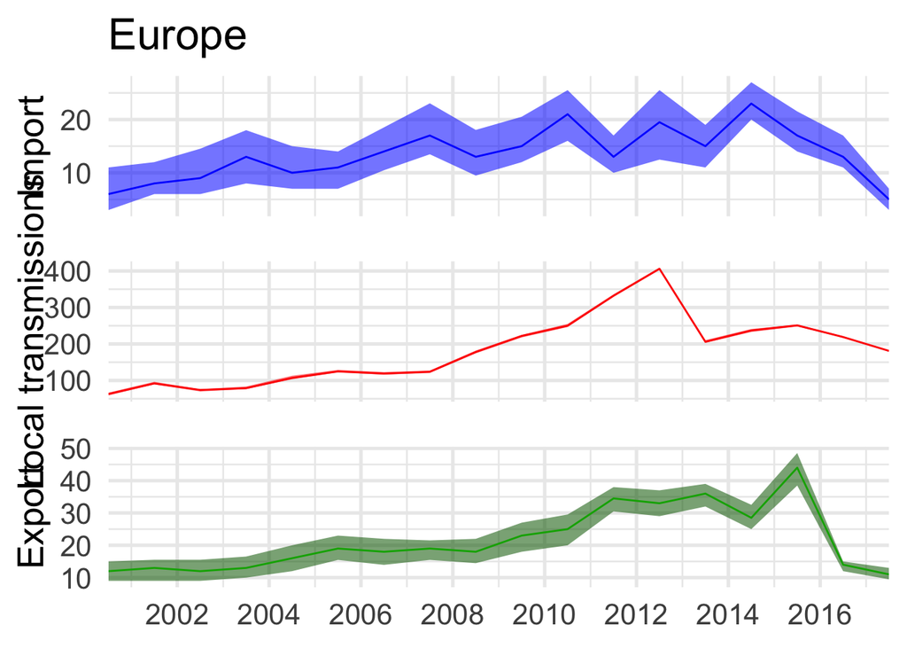